# Feed and Supply Marketing Strategy for Rural Area Business

### By Mia Murphy

#### 12/01/2023

For a marketing strategy focused on a small, rural feed and supply company in the Upper Valley area, specifically between White River Junction, Vermont, and West Lebanon, New Hampshire, understanding the local demographics is crucial. Here's a summary of the demographic information for these areas:

## White River Junction, Vermont:

- **Population**: Approximately 2,776 residents.
- **Median Age**: 37.5 years, which is slightly lower than the state average of 42.7 years.
- **Income**: The estimated median household income in 2021 was $60,906.
- **Racial Composition**: Predominantly White (85.3%), with smaller percentages of other races including Black or African American (0.9%).

## West Lebanon, New Hampshire:

- **Population**: Around 4,261 people.
- **Population Growth Rate**: The area is experiencing a growth rate of 3.93%.
- **Median Household Income**: In 2021, it was $66,934.
- **Racial Composition**: Majority White (83.2%), with notable Asian (10.88%) and Black (3.31%) populations.

## Lebanon, New Hampshire (for broader context):

- **Population**: 16,431 residents, showing a significant increase since 2020.
- **Median Age**: 38.1 years, with a slightly higher age median for females (40.3 years).
- **Gender Distribution**: Females constitute a slightly larger part of the population (53.44%).
- **Racial Composition**: Predominantly White (87.88%), followed by Asian (5.15%) and Black or African American (2.35%).

## Dog Ownership Statistics in Vermont and New Hampshire:

- In Vermont, more than two-thirds of residents (70.8%) own at least one pet.
- Vermont has a high rate of cat ownership at 49.5% and, while not in the top 10 states for dog ownership, still has a considerable dog ownership rate of 37.7%.
- New Hampshire's overall pet ownership rate is 51.8%, with 23.7% of households owning dogs.

## Marketing Strategy Implications:

1. **Target Audience**:
   - Focus on adults in the age range of 37-40 years, as they form a significant part of the population.
   - Tailor marketing efforts to appeal to a predominantly White demographic, but also consider the notable Asian and Black communities in West Lebanon.
2. **Income Sensitivity**:
   - Given the median income levels, marketing strategies should consider the affordability of products, offering a range of options to cater to diverse income groups.
3. **Community Engagement**:
   - Plan events and promotions that resonate with the local community's interests and demographics.
   - Consider family-oriented marketing strategies, as the demographics suggest a significant portion of the population might be families.
4. **Social Media and Advertising**:
   - Use social media platforms to target the adult population effectively, focusing on content that appeals to the 37-40 age range.
   - Develop advertising campaigns that reflect the local community's demographic makeup, ensuring inclusivity and relevance.
5. **Product Diversification**:
   - Given the diverse needs of the community, consider expanding the range of products to cater to different preferences and needs.

## Community Engagement, Brand Loyalty and Local Competition

1. **Target Market Analysis**:
   - **Age and Income Brackets**: Tailor marketing messages to resonate with the primary age groups identified in the survey. Offer pricing and deals that align with the predominant income brackets.
   - **Dog Owners**: Since a significant portion of the respondents are dog owners, the marketing strategy should heavily focus on dog-related products, services, and information.
2. **Purchasing Location Preferences**:
   - Analyze the data to understand why some customers prefer shopping at places like Home Depot or grocery stores. This insight can help in adjusting product offerings, pricing, and marketing tactics.
   - Enhance the in-store experience to compete effectively with these larger stores. Personalized customer service and unique product offerings can be a differentiator.
3. **Community Engagement Strategies**:
   - **Events Sponsorship**: Plan and sponsor local events that resonate with the community, such as dog shows, pet adoption days, and local fairs. These events can enhance visibility and brand recognition.
   - **Partnerships with Local Organizations**: Collaborate with local shelters, dog clubs, or schools to create community-centric initiatives. This not only boosts visibility but also demonstrates commitment to community welfare.
4. **Social Media and Online Presence**:
   - Given the high usage of social media for local business information, an active online presence is crucial. Regular posts, engaging content, and interactive campaigns can draw in the digital audience.
   - Utilize social media analytics to track engagement and tailor content to the preferences of the audience. Also, consider online sales or promotions exclusive to social media followers.
5. **Feedback and Continuous Improvement**:
   - Implement a system for collecting ongoing customer feedback, both in-store and online. This feedback can guide future product offerings, services, and marketing strategies.
   - Regularly update the product line and services based on customer preferences and market trends, especially focusing on high-demand items like dog food.
6. **Local SEO and Online Marketing**:
   - Invest in local SEO strategies to ensure that the company appears in search results for relevant queries in the Upper Valley region.
   - Use targeted online advertising to reach potential customers in the specific geographic areas of White River Junction, Vermont, and West Lebanon, New Hampshire.
7. **Educational Workshops and Demonstrations**:
   - Host educational events on pet care, nutrition, and other relevant topics. This not only positions the company as an expert in the field but also increases customer engagement and loyalty.

## Example of an Email Survey and Data Visuals

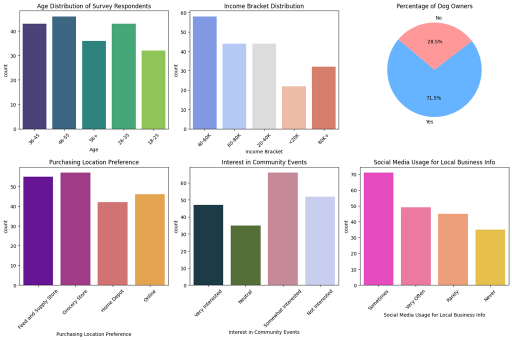

```python
import pandas as pd
import numpy as np
import matplotlib.pyplot as plt
import seaborn as sns
import warnings
warnings.filterwarnings('ignore', category=FutureWarning)

# Sample data generation for the survey results
np.random.seed(0)
survey_data = pd.DataFrame({
    "Age": np.random.choice(["18-25", "26-35", "36-45", "46-55", "56+"], 200, p=[0.15, 0.25, 0.20, 0.20, 0.20]),
    "Income Bracket": np.random.choice(["<20K", "20-40K", "40-60K", "60-80K", "80K+"], 200, p=[0.10, 0.20, 0.30, 0.25, 0.15]),
    "Dog Owner": np.random.choice(["Yes", "No"], 200, p=[0.7, 0.3]),
    "Purchasing Location Preference": np.random.choice(["Feed and Supply Store", "Grocery Store", "Home Depot", "Online"], 200, p=[0.25, 0.25, 0.25, 0.25]),
    "Interest in Community Events": np.random.choice(["Very Interested", "Somewhat Interested", "Neutral", "Not Interested"], 200, p=[0.25, 0.30, 0.20, 0.25]),
    "Social Media Usage for Local Business Info": np.random.choice(["Very Often", "Sometimes", "Rarely", "Never"], 200, p=[0.25, 0.35, 0.25, 0.15])
})

# Visualizations
plt.figure(figsize=(15, 10))

# Age Distribution
plt.subplot(2, 3, 1)
sns.countplot(x="Age", data=survey_data, palette="viridis")  # Using a different palette
plt.title("Age Distribution of Survey Respondents")
plt.xticks(rotation=45)

# Income Bracket Distribution
plt.subplot(2, 3, 2)
sns.countplot(x="Income Bracket", data=survey_data, palette="coolwarm")  # Using a different palette
plt.title("Income Bracket Distribution")
plt.xticks(rotation=45)

# Dog Owner Percentage
plt.subplot(2, 3, 3)
dog_owner_counts = survey_data["Dog Owner"].value_counts()
plt.pie(dog_owner_counts, labels=dog_owner_counts.index, autopct='%1.1f%%', startangle=140, colors=["#66b3ff","#ff9999"])  # Specifying colors
plt.title("Percentage of Dog Owners")

# Purchasing Location Preference
plt.subplot(2, 3, 4)
sns.countplot(x="Purchasing Location Preference", data=survey_data, palette="plasma")  # Using a different palette
plt.title("Purchasing Location Preference")
plt.xticks(rotation=45)

# Interest in Community Events
plt.subplot(2, 3, 5)
sns.countplot(x="Interest in Community Events", data=survey_data, palette="cubehelix")  # Using a different palette
plt.title("Interest in Community Events")
plt.xticks(rotation=45)

# Social Media Usage for Local Business Info
plt.subplot(2, 3, 6)
sns.countplot(x="Social Media Usage for Local Business Info", data=survey_data, palette="spring")  # Using a different palette
plt.title("Social Media Usage for Local Business Info")
plt.xticks(rotation=45)

plt.tight_layout()
plt.show()
```

1. **Age Distribution of Survey Respondents**: This chart displays the age range of respondents, helping to understand the primary age group the company should target.
2. **Income Bracket Distribution**: This graph shows the income bracket of the survey participants, which is crucial for pricing and marketing strategies.
3. **Percentage of Dog Owners**: A pie chart indicating the proportion of dog owners among the respondents. Since dog food is a best seller, this data is vital for targeting the right audience.
4. **Purchasing Location Preference**: This graph presents the preferred purchasing locations of the respondents, highlighting potential competition and where customers are currently buying their supplies.
5. **Interest in Community Events**: The chart shows the level of interest in community events among the participants, which is key for planning community engagement strategies.
6. **Social Media Usage for Local Business Info**: This illustrates how often respondents use social media to get information about local businesses, guiding the company's online engagement efforts.

**Note**: The above sample is using hypothetical data and a survey would need to be completed to generate accurate data and visualizations.